# Survival Analysis; Hypothesis testing and Regression

Hana Akbarnejad

4/30/2020

### Hypothesis Testing: Log-rank Test to compare hazard functions between two groups

```r
# creating data frame...
surv_data =
  tibble (
    time = c(4, 12, 15, 21, 23, 2, 6, 8, 10, 19),
    delta = c(1, 0, 1, 0, 1, 1, 0, 0, 1, 1), #0:censored, 1:event
    group = c(1, 1, 1, 1, 1, 2, 2, 2, 2, 2)
  )

#log rank test
survdiff(Surv(time,delta)~group, data=surv_data)
```

```
## Call:
## survdiff(formula = Surv(time, delta) ~ group, data = surv_data)
##
##         N Observed Expected (O-E)^2/E (O-E)^2/V
## group=1 5        3     4.14     0.313      1.15
## group=2 5        3     1.86     0.697      1.15
##
##  Chisq= 1.1  on 1 degrees of freedom, p= 0.3
```

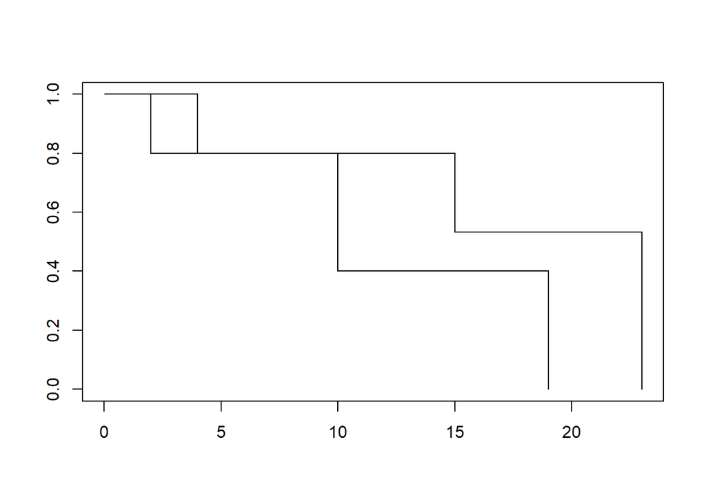

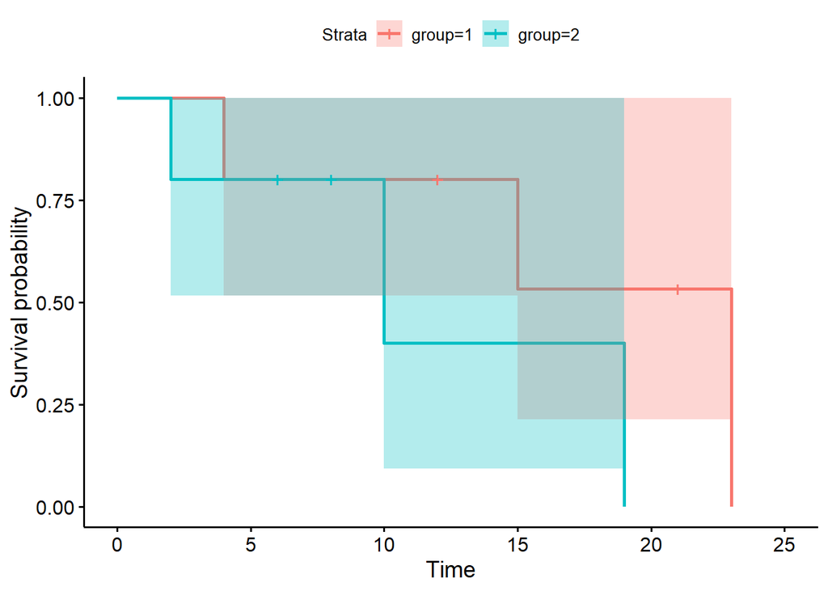

```r
#plotting
plot(survfit(Surv(time,delta)~group, data = surv_data))
ggsurvplot( survfit(Surv(time, delta) ~ group, data = surv_data), conf.int=TRUE)
```

We want to test $H_0: h_1(t) = h_2(t)$ versus $H_1:h_1(t) \neq h_2(t)$.

### Comparing death times of kidney transplant patients in different race/sex groups

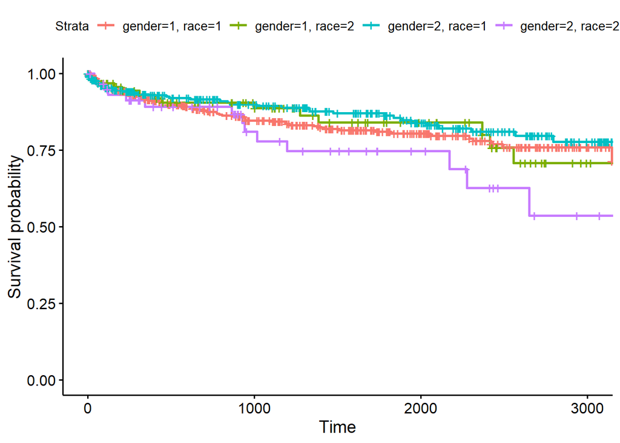

```r
data("kidtran")
kidtran_data = kidtran %>%
  mutate(
    gender = as.factor(gender),
    race = as.factor(race)
  )

# levels(kidtran_data$gender)  #1:Male, 2:Female
# levels(kidtran_data$race)    #1:white, 2: black

# Surv(kidtran_data$time, kidtran_data$delta,type='right')

#survfit(Surv(time, delta) ~ gender + race, data = kidtran_data)

ggsurvplot(survfit(Surv(time, delta) ~ gender + race, data = kidtran_data), conf.int=FALSE)
```

```r
# male model
male_surv = survdiff(Surv(time, delta)~ gender + race, data = kidtran_data, subset = (gender == 1))
male_surv
```

```
## Call:
## survdiff(formula = Surv(time, delta) ~ gender + race, data = kidtran_data,
##     subset = (gender == 1))
##
##                    N Observed Expected (O-E)^2/E (O-E)^2/V
## gender=1, race=1 432       73     71.9    0.0168     0.097
## gender=1, race=2  92       14     15.1    0.0801     0.097
##
##  Chisq= 0.1  on 1 degrees of freedom, p= 0.8
```

```r
#female model
female_surv = survdiff(Surv(time, delta)~ gender + race, data = kidtran_data, subset = (gender == 2))
female_surv
```

```
## Call:
## survdiff(formula = Surv(time, delta) ~ gender + race, data = kidtran_data,
##     subset = (gender == 2))
##
##                    N Observed Expected (O-E)^2/E (O-E)^2/V
## gender=2, race=1 280       39    44.79     0.748      4.85
## gender=2, race=2  59       14     8.21     4.076      4.85
##
##  Chisq= 4.8  on 1 degrees of freedom, p= 0.03
```

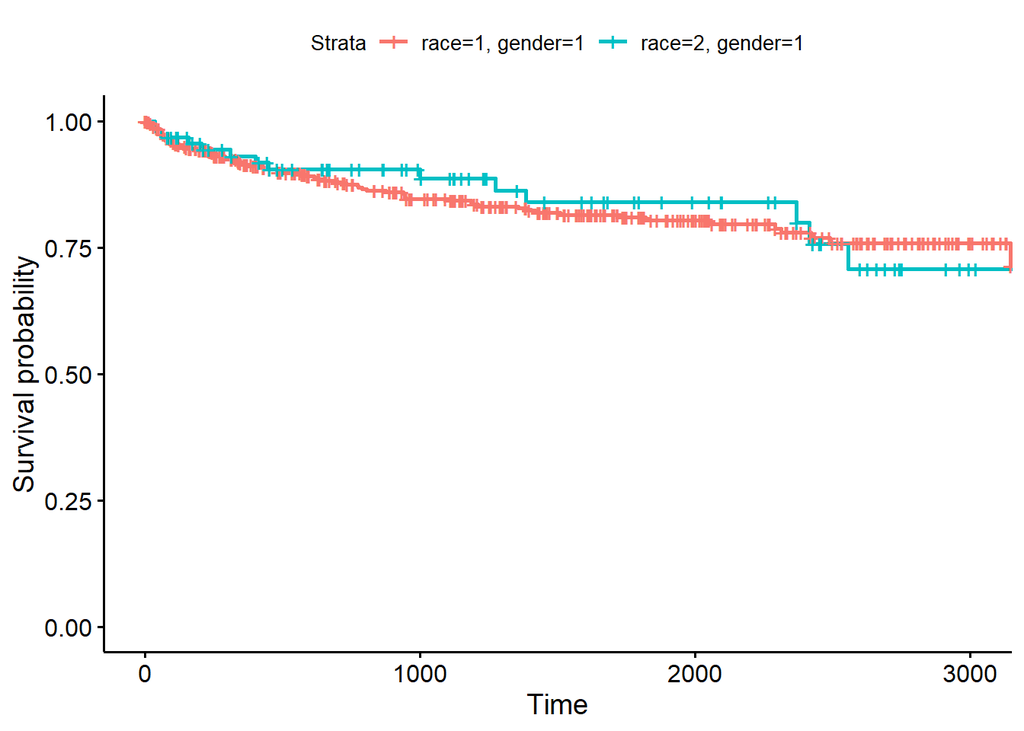

```r
#male plot
ggsurvplot(survfit(Surv(time, delta) ~ race+gender, data = kidtran_data, subset = (gender == 1) ), conf.int=FALSE)
```

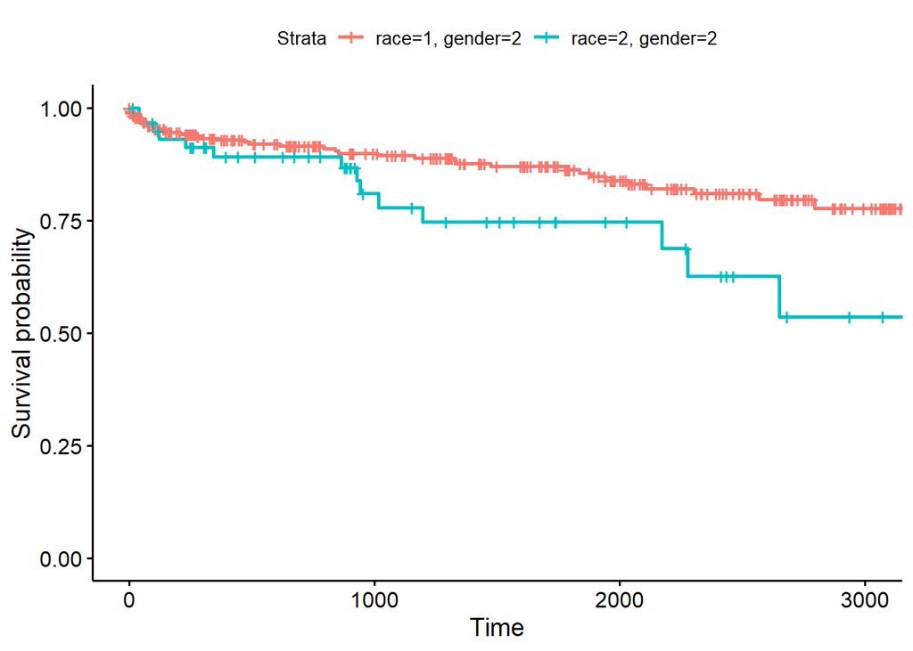

```r
#female plot
ggsurvplot(survfit(Surv(time, delta) ~ race+gender, data = kidtran_data, subset = (gender == 2) ), conf.int=FALSE)
```

Comparing survival of male subjects, we can observe that p-value is 0.8 which is greater than 0.05. This means that we fail to reject H_0 and conclude that there is no statistically significant difference in survival of white men versus black men. We can also observe that in the plot that shows survival plot of different races in male subjects, the curve are pretty close to each other.

### Proportional Hazards(PH) Model, survival of different stages of Larynx Cancer patients

```r
data("larynx")
larynx_data = larynx %>%
  mutate(
    z1 = if_else(stage == 2, 1, 0),
    z2 = if_else(stage == 3, 1, 0),
    z3 = if_else(stage == 4, 1, 0),
    z4 = age,
    z1 = as.factor(z1),
    z2 = as.factor(z2),
    z3 = as.factor(z3),
  ) %>%
  select(time, diagyr, delta, z1:z4)

ph_fir = coxph(Surv(time,delta)~z2+z3+z1*z4,data=larynx_data,ties='breslow')
ph_fir
```

```
## Call:
## coxph(formula = Surv(time, delta) ~ z2 + z3 + z1 * z4, data = larynx_data,
##     ties = "breslow")
##
##              coef  exp(coef)   se(coef)      z        p
## z21     0.6218044  1.8622853  0.3558078  1.748   0.0805
## z31     1.7534270  5.7743576  0.4239595  4.136 3.54e-05
## z11    -7.3820143  0.0006223  3.4027542 -2.169   0.0301
## z4      0.0059729  1.0059908  0.0148792  0.401   0.6881
## z11:z4  0.1116674  1.1181409  0.0476728  2.342   0.0192
##
## Likelihood ratio test=24.11  on 5 df, p=0.0002068
## n= 90, number of events= 50
```

The model is: $h_i(t)=h_0(t) e^{\beta_1 Z_1 + \beta_2 Z_2 + \beta_3 Z_3 + \beta_4 Z_4 + \beta_5 Z1 * Z4 }$

$$h_i(t)=h_0(t) e^{-7.38Z_1 + 0.62Z_2 + 1.75Z_3 + 0.006 Z_4 + 0.11Z1 * Z4 }$$

$\beta_1 + \beta_5:$ The log hazard ratio of time to death or censoring (Is this right?) between participants in stageII versus those in stageI is -7.27 (0.11-7.38), for a specific age(?).

$\beta_2:$ The log hazard ratio of time to death or censoring between participants in stageIII versus those in stageI is 0.62, holding age constant.

$\beta_3:$ The log hazard ratio of time to death or censoring between participants in stageIV versus those in stageI is 1.75, holding age constant.

$\beta_4 + \beta_5:$ The log hazard ratio of time to death or censoring for participants in stageII versus is 0.116 (0.11+ 0.006), per 1 unit increase in age.

(I think!) when we include interaction term we shouldn’t interpret individual effects. > check interpretations!

- What is the relative risk of dying for a stage II patient of age 50 as compared to a stage I patient of the same age?

$$h_2(t) = h_0(t) \times exp(−7.38 × 1 + 0.11 × 1 × 50)$$

For the hazard of dying for a stage I patient of age 50 is:

$$h_1(t) = h_0(t)exp(0)$$

So, the hazard ratio: $HR(t) = \frac{h_2(t)}{h_1(t)} = 0.16$